# Event-specific NOAA DHW correction

Authenticated AIMS logger extraction, depth diagnostics and mortality-model validation

## Decision summary

The authenticated AIMS data support an event-specific NOAA correction layer, but not a universal Lizard-region uplift. Discrepancies have moderate cross-event persistence, while their magnitude and even their sign vary among sites and years. The production-safe form is therefore a partially pooled spatial surface trained only on previous events. A second, within-event surface is retained for retrospective analysis or operational updating once enough current-event logger data exist.

The historical correction modestly improves leave-one-event-out mortality RMSE from 0.1973 to 0.1942. The within-event layer raises exposure at the principal 2024 Lizard-region misses, but does not resolve their severe mortality and slightly worsens GBR-wide event-transfer RMSE to 0.2000. Local heat underestimation is therefore one contributor, not the whole explanation; freshwater, community composition and other compound pressures remain necessary.

## Reproducible authenticated extraction

`scripts/pull_aims_temperature_data.R` downloads the complete AIMS temperature deployment catalogue, retains deployment depth, and downloads every daily logger record in the prespecified bleaching-event windows. It can also add automated weather/ocean-station water temperatures. Raw responses are cached under `data/raw/aims_temperature/api/`; the key is read only from `AIMS_DATAPLATFORM_API_KEY` and is never written into the repository or report.

The default extraction covers 2016, 2017, 2020, 2022 and 2024. Years, refresh behaviour and automated-station scope are configuration values, so expansion does not require code changes.

AIMS–NOAA comparisons by event, source, depth and coverage

| event_year | source | depth_class | adequate_dhw_coverage | series_events |
| --- | --- | --- | --- | --- |
| 2016 | automated_weather | deep_gt5m | TRUE | 1 |
| 2016 | automated_weather | shallow_0_5m | TRUE | 1 |
| 2016 | temperature_logger | deep_gt5m | TRUE | 4 |
| 2016 | temperature_logger | deep_gt5m | FALSE | 2 |
| 2016 | temperature_logger | shallow_0_5m | TRUE | 4 |
| 2016 | temperature_logger | shallow_0_5m | FALSE | 4 |
| 2016 | temperature_logger | unknown | TRUE | 135 |
| 2016 | temperature_logger | unknown | FALSE | 24 |
| 2017 | automated_weather | deep_gt5m | TRUE | 1 |
| 2017 | automated_weather | shallow_0_5m | FALSE | 1 |
| 2017 | temperature_logger | deep_gt5m | TRUE | 8 |
| 2017 | temperature_logger | shallow_0_5m | TRUE | 6 |
| 2017 | temperature_logger | shallow_0_5m | FALSE | 1 |
| 2017 | temperature_logger | unknown | TRUE | 172 |
| 2017 | temperature_logger | unknown | FALSE | 7 |
| 2020 | automated_weather | deep_gt5m | TRUE | 1 |
| 2020 | automated_weather | deep_gt5m | FALSE | 2 |
| 2020 | automated_weather | shallow_0_5m | TRUE | 1 |
| 2020 | automated_weather | shallow_0_5m | FALSE | 1 |
| 2020 | temperature_logger | shallow_0_5m | TRUE | 2 |
| 2020 | temperature_logger | unknown | TRUE | 200 |
| 2020 | temperature_logger | unknown | FALSE | 5 |
| 2022 | automated_weather | deep_gt5m | TRUE | 1 |
| 2022 | automated_weather | deep_gt5m | FALSE | 1 |
| 2022 | automated_weather | shallow_0_5m | TRUE | 1 |
| 2022 | temperature_logger | unknown | TRUE | 163 |
| 2022 | temperature_logger | unknown | FALSE | 10 |
| 2024 | automated_weather | deep_gt5m | FALSE | 1 |
| 2024 | automated_weather | shallow_0_5m | TRUE | 1 |
| 2024 | temperature_logger | unknown | TRUE | 148 |
| 2024 | temperature_logger | unknown | FALSE | 9 |

## GBR-wide logger discrepancy

Logger DHW is reconstructed from quality-controlled daily AIMS temperatures, the collocated NOAA maximum monthly mean, and the NOAA 84-day HotSpot threshold definition. A comparison is accepted only when at least 70 days are available in the 84-day window at the eligible logger-DHW peak.

Coverage-qualified AIMS comparisons by bleaching event

| event_year | adequate_series | sites | median_logger_minus_NOAA_DHW | q10 | q90 | NOAA_underestimated_fraction |
| --- | --- | --- | --- | --- | --- | --- |
| 2016 | 145 | 82 | -0.16 | -2.17 | 2.44 | 0.35 |
| 2017 | 187 | 102 | -0.21 | -2.46 | 2.99 | 0.44 |
| 2020 | 204 | 106 | -0.25 | -4.31 | 2.92 | 0.43 |
| 2022 | 165 | 90 | -0.49 | -3.91 | 1.94 | 0.35 |
| 2024 | 149 | 81 | -1.53 | -6.26 | 1.98 | 0.32 |

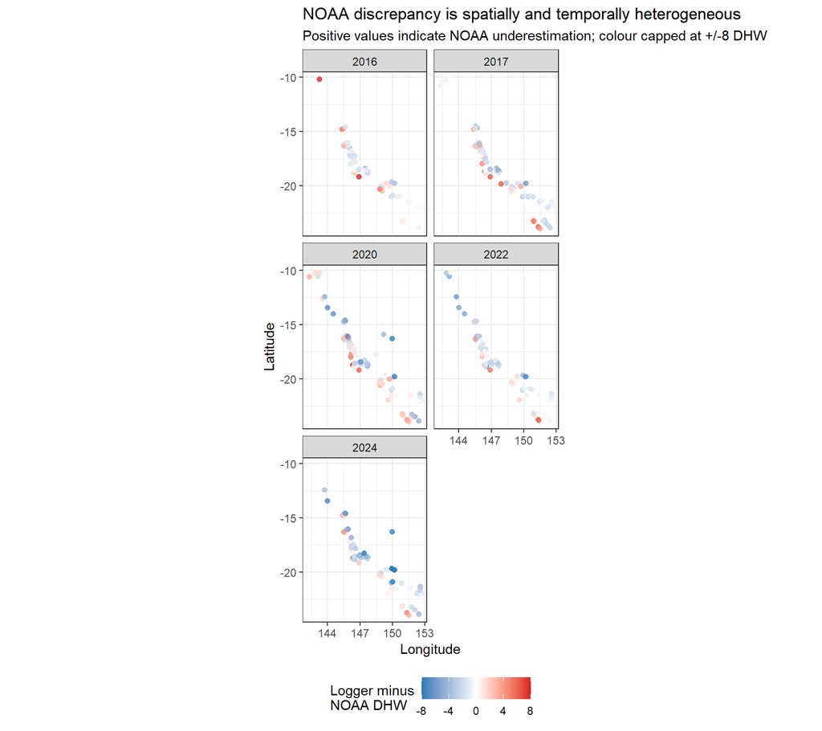

Across series observed in multiple events, discrepancy ranks are moderately persistent (event-pair Spearman correlations approximately 0.59–0.73), but extreme individual logger anomalies mean interpolation uncertainty must be retained.

## Depth: use it for record selection, not an unstable slope

NOAA is a surface-temperature product. The correction builder therefore prefers shallow/reef-flat records (0–5 m) within each site-event and uses deep records only where a shallow record is unavailable. It retains all depths in the audit output.

Only 5 coverage-qualified site-events currently contain paired shallow and deep series. Their median shallow-minus-deep discrepancy is 0.50 DHW. That is not enough replication to estimate a reliable continuous depth effect or a separate deep correction surface.

Coverage-qualified paired shallow–deep diagnostics

| Event | Site | Shallow depth (m) | Deep depth (m) | Shallow minus deep discrepancy (DHW) |
| --- | --- | --- | --- | --- |
| 2016 | Erskine Island | 4.0 | 8.5 | 0.00 |
| 2016 | Lizard Island | 0.6 | 10.1 | -0.33 |
| 2017 | Erskine Island | 4.0 | 8.5 | 0.50 |
| 2020 | Lizard Island | 0.6 | 9.0 | 4.68 |
| 2022 | Lizard Island | 5.0 | 10.0 | 0.72 |

At Lizard Island in 2016, the authenticated automated station adds a 0.6 m series and a 10.1 m series. Their reconstructed logger-minus-NOAA discrepancies are -0.68 and -0.35 DHW respectively. Thus 2016 NOAA underestimation was not uniform across the Lizard region: it is strong at Linnet and Martin, but not at the Lizard Island station itself.

## Event-specific spatial correction

The correction aggregates to site-event, partially pools each site’s historical discrepancy toward zero according to the number of previous events, and interpolates from at most eight nearby logger sites. Spatial ranges were screened with both held-out sites and held-out whole events.

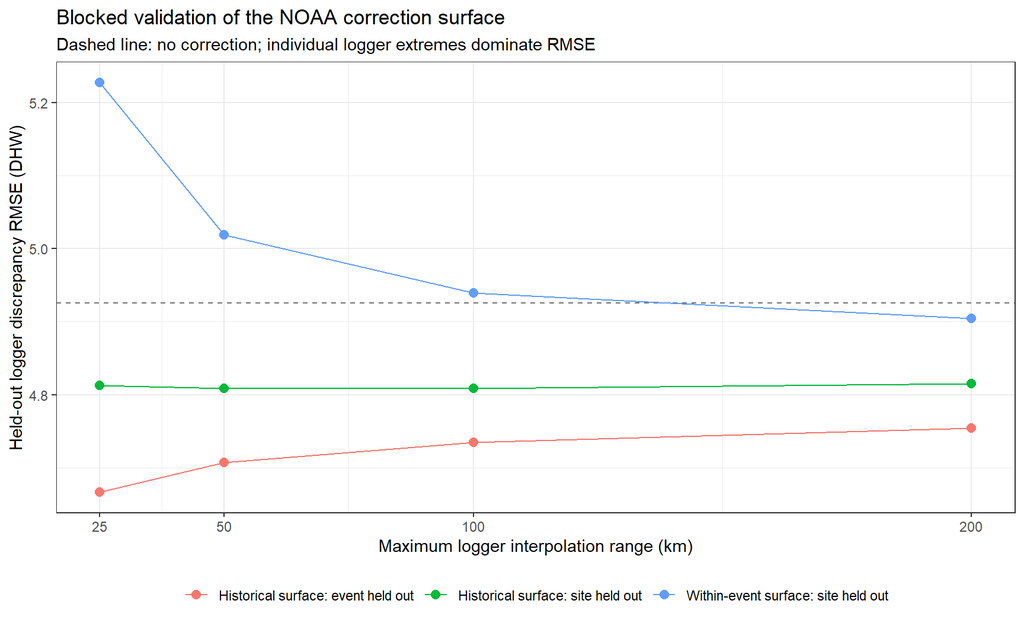

The selected historical surface uses a 100 km range; the within-event update uses 200 km to estimate the broader event offset. The historical surface improves event-held-out logger-discrepancy RMSE from 4.93 to 4.73 DHW at the selected 100 km range, and its best screened event-held-out value is 4.67 DHW at 25 km. Selection uses the site-held-out criterion to avoid tuning only to years.

## Mortality-model validation

INLA validation with unchanged and logger-corrected DHW

| DHW_input | validation | RMSE | MAE | predictive_R2 | bias | occurrence_Brier | severe_RMSE | false_extreme_rate | WAIC | DIC |
| --- | --- | --- | --- | --- | --- | --- | --- | --- | --- | --- |
| Historical logger surface | Leave-one-event-out | 0.194 | 0.137 | -0.197 | 0.034 | 0.260 | 0.399 | 0.113 | 177.379 | 175.850 |
| NOAA unchanged | Leave-one-event-out | 0.197 | 0.138 | -0.236 | 0.038 | 0.252 | 0.407 | 0.113 | 178.934 | 178.346 |
| Within-event logger surface | Leave-one-event-out | 0.200 | 0.142 | -0.271 | 0.024 | 0.267 | 0.420 | 0.139 | 178.058 | 178.640 |
| NOAA unchanged | Reef-blocked 5-fold | 0.136 | 0.090 | 0.415 | -0.002 | 0.188 | 0.325 | 0.037 | 178.934 | 178.346 |
| Within-event logger surface | Reef-blocked 5-fold | 0.137 | 0.091 | 0.407 | -0.005 | 0.191 | 0.315 | 0.037 | 178.058 | 178.640 |
| Historical logger surface | Reef-blocked 5-fold | 0.137 | 0.090 | 0.406 | -0.001 | 0.190 | 0.326 | 0.046 | 177.379 | 175.850 |

Reef-blocked performance is essentially unchanged across the three inputs. For transfer to an unseen event, the historical surface is strongest by RMSE and severe-case RMSE. The within-event surface cannot be interpreted as prospective leave-event-out information; it is a retrospective/current-event update.

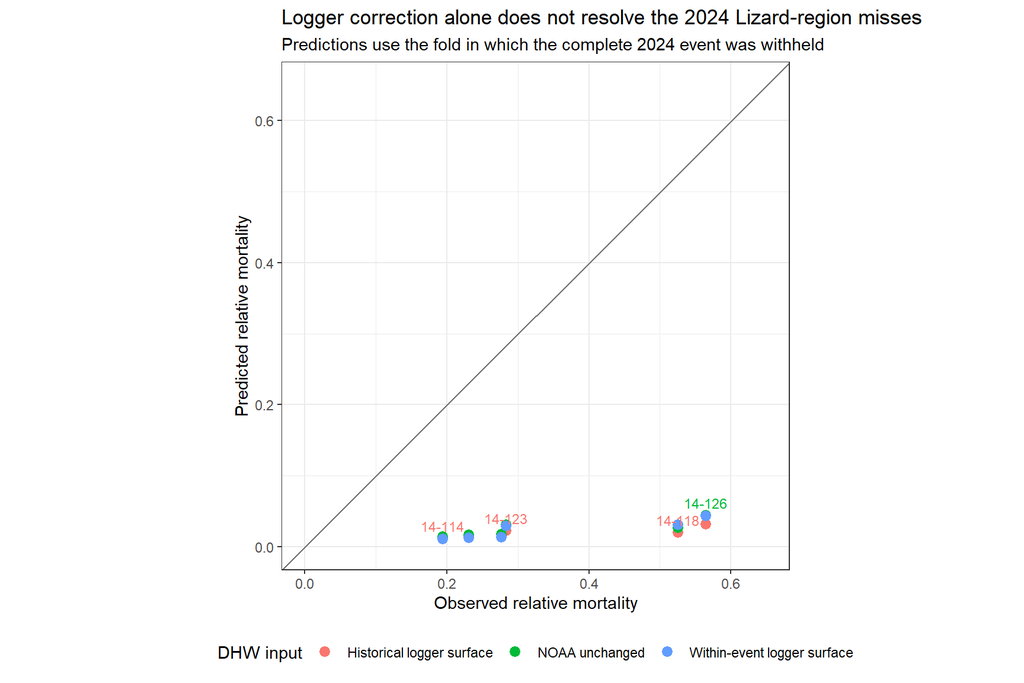

2024 Lizard-region leave-event-out predictions

| ReefID | ReefName | DHW_input | NOAA_DHW | correction_DHW | model_DHW | observed | predicted |
| --- | --- | --- | --- | --- | --- | --- | --- |
| 14-114 | MacGillivray Reef (14-114) | Historical logger surface | 5.93 | -0.492 | 5.438 | 0.194 | 0.012 |
| 14-114 | MacGillivray Reef (14-114) | NOAA unchanged | 5.93 | 0.000 | 5.930 | 0.194 | 0.014 |
| 14-114 | MacGillivray Reef (14-114) | Within-event logger surface | 5.93 | 0.550 | 6.480 | 0.194 | 0.011 |
| 14-116a | Lizard Island Reef (North West) (14-116a) | Historical logger surface | 6.27 | -0.420 | 5.850 | 0.231 | 0.014 |
| 14-116a | Lizard Island Reef (North West) (14-116a) | NOAA unchanged | 6.27 | 0.000 | 6.270 | 0.231 | 0.016 |
| 14-116a | Lizard Island Reef (North West) (14-116a) | Within-event logger surface | 6.27 | 0.647 | 6.917 | 0.231 | 0.013 |
| 14-118 | Eyrie Reef (14-118) | Historical logger surface | 6.27 | -0.268 | 6.002 | 0.526 | 0.020 |
| 14-118 | Eyrie Reef (14-118) | NOAA unchanged | 6.27 | 0.000 | 6.270 | 0.526 | 0.026 |
| 14-118 | Eyrie Reef (14-118) | Within-event logger surface | 6.27 | 0.836 | 7.106 | 0.526 | 0.030 |
| 14-123 | Martin Reef (14-123) | Historical logger surface | 6.40 | -0.176 | 6.224 | 0.284 | 0.022 |
| 14-123 | Martin Reef (14-123) | NOAA unchanged | 6.40 | 0.000 | 6.400 | 0.284 | 0.031 |
| 14-123 | Martin Reef (14-123) | Within-event logger surface | 6.40 | 0.939 | 7.339 | 0.284 | 0.029 |
| 14-126 | Linnet Reef (14-126) | Historical logger surface | 6.73 | -0.153 | 6.577 | 0.564 | 0.032 |
| 14-126 | Linnet Reef (14-126) | NOAA unchanged | 6.73 | 0.000 | 6.730 | 0.564 | 0.044 |
| 14-126 | Linnet Reef (14-126) | Within-event logger surface | 6.73 | 0.957 | 7.687 | 0.564 | 0.043 |
| 14-143 | North Direction Reef (14-143) | Historical logger surface | 6.23 | -0.390 | 5.840 | 0.277 | 0.013 |
| 14-143 | North Direction Reef (14-143) | NOAA unchanged | 6.23 | 0.000 | 6.230 | 0.277 | 0.018 |
| 14-143 | North Direction Reef (14-143) | Within-event logger surface | 6.23 | 0.692 | 6.922 | 0.277 | 0.014 |

## Operational recommendation

1. Retain NOAA DHW as the base exposure and store the correction as a separate, versioned field with distance, effective logger count and correction mode.
2. Use the historical-only correction for genuinely prospective predictions; it uses no logger observations from the event being predicted.
3. Update to the within-event correction only after prespecified coverage and spatial-support thresholds are met, and label those predictions as updated.
4. Prefer 0–5 m logger records for surface calibration, fall back to deeper records where necessary, and keep shallow/deep diagnostics. Do not estimate a continuous depth coefficient until substantially more paired events exist.
5. Propagate correction uncertainty into the INLA predictor rather than treating corrected DHW as known exactly. The current screen tests the mean only.
6. Keep the older fixed +4.82 DHW Lizard uplift solely as a stress-test. It is informative mechanistically but is not a calibrated GBR-wide product.